Skip to main content

# The N400: Semantic Relatedness in Word-Pair Processing

Author

Kashish Shah

Published

November 2, 2026

## Introduction

### Characteristics and discovery of the N400

The N400 is a negative-going event-related potential (ERP) associated with the processing of meaningful stimuli. It typically develops approximately 200–300 ms after stimulus onset and is prominent around 400 ms, although its timing and duration vary with the task and stimulus. For visually presented words, the effect commonly has a broad centroparietal distribution, with substantial activity at central and parietal electrodes. Crucially, the N400 is generally described in terms of amplitude differences between conditions, rather than the presence of a unique negative peak in every waveform (Kutas & Federmeier, 2011). In the ERP CORE word-pair paradigm, the representative electrode is CPz and the recommended measurement window is 300–500 ms after target-word onset (Kappenman et al., 2021). The component was first reported by Kutas and Hillyard in 1980. Participants read sentences that ended with either contextually appropriate words or semantically anomalous completions. Unexpected endings elicited a larger negative response around 400 ms, demonstrating that scalp-recorded brain activity was sensitive to linguistic meaning rather than only the physical characteristics of a stimulus (Kutas & Hillyard, 1980). This discovery established ERPs as a valuable method for investigating the time course of language comprehension.

### Conditions that elicit the N400

Subsequent research established that N400 amplitude varies systematically with semantic context. Words that are difficult to relate to preceding information tend to elicit larger negative responses than words supported by context. The effect occurs in sentences, isolated word pairs, and other meaningful stimulus sequences; it is not restricted to obvious grammatical or semantic violations (Kutas & Federmeier, 2011).

In semantic priming experiments, a target such as *butter* following *bread* generally elicits a smaller N400 than the same target following an unrelated prime. Context can facilitate the processing of a word even when both alternatives are meaningful and grammatically acceptable. N400-like effects have also been investigated with pictures, environmental sounds and other conceptually meaningful stimuli, supporting the view that the component is not exclusively a response to written language (Kutas & Federmeier, 2011; Lau et al., 2008).

### Functional significance and theoretical debate

The N400 is widely interpreted as an electrophysiological index of meaning-related processing, but the precise cognitive operation it reflects remains debated. One account emphasises access to or activation of semantic representations: related context preactivates relevant information, reducing the processing required when the target appears. Another emphasises the ease of integrating the target into an evolving representation of context. These interpretations are difficult to distinguish because semantic access, contextual expectations and integration frequently covary in natural language (Lau et al., 2008).

More recent frameworks treat N400 amplitude as sensitive to the degree of contextual support for a stimulus, without equating the component with a single, isolated stage of comprehension (Kutas & Federmeier, 2011).

The present report examines the N400 using the ERP CORE word-pair judgement task. Participants saw related and unrelated prime–target pairs, allowing comparison of target-locked ERPs. Based on previous research, unrelated targets are expected to elicit a more negative-going waveform than related targets at CPz during the 300–500 ms measurement window (Kappenman et al., 2021).

## Methods

### Participants

The ERP CORE resource originally included 40 neurotypical young adults from the University of California, Davis community (25 female, 15 male; mean age 21.5 years, SD = 2.87; age range 18–30 years). Thirty-eight participants were right-handed.

Participants reported native English competence, normal colour perception, normal or corrected-to-normal vision and no history of neurological injury or disease. All provided informed consent.

The original N400 analysis retained 39 participants after task-specific exclusions, including criteria concerning artefact-contaminated trials, response accuracy and the number of trials remaining in each condition (Kappenman et al., 2021).

Of the 40 available EEG recordings, 39 participants contributed usable epochs to both semantic relatedness conditions and were included in the present grand-average analysis. One participant was excluded because the data did not meet the criteria for inclusion in both conditions.

The dataset was made available through the ERP CORE resource under the Creative Commons Attribution-ShareAlike 4.0 International (CC BY-SA 4.0) licence.

### Procedure

The N400 was elicited using a semantic word-pair judgement task. Each trial presented a red prime word followed by a green target word. Participants indicated by button press whether the target was semantically related or unrelated to the prime.

The experiment contained 120 trials: 60 related and 60 unrelated, organised into blocks of 20. Each target appeared in both a related and an unrelated context across the experiment.

The prime was displayed for 200 ms, followed by an interstimulus interval of 900–1100 ms. The target was displayed for 200 ms, followed by an intertrial interval of 1400–1600 ms.

The N400 analysis was time-locked to the onset of the target word rather than the prime word (Kappenman et al., 2021).

### EEG recording

Continuous EEG was acquired using a BioSemi ActiveTwo system with active electrodes positioned in an elastic cap.

Thirty scalp electrodes were positioned according to the international 10–20 system: Fp1, F3, F7, FC3, C3, C5, P3, P7, P9, PO7, PO3, O1, Oz, Pz, CPz, Fp2, Fz, F4, F8, FC4, FCz, Cz, C4, C6, P4, P8, P10, PO8, PO4 and O2.

The common mode sense (CMS) electrode was positioned at PO1 and the driven right leg (DRL) electrode at PO2.

Horizontal electrooculography (EOG) was recorded using electrodes positioned lateral to both eyes. Vertical EOG was recorded below the right eye and combined with Fp2 offline.

Signals were acquired at a sampling frequency of 1024 Hz with 24-bit resolution. A fifth-order sinc acquisition low-pass filter was applied, with a half-power cutoff of 204.8 Hz.

EEG referencing was performed offline (Kappenman et al., 2021).

### Analysis parameters

The present analysis uses the supplied mini_mne preprocessing pipeline. The EEG data are re-referenced to the average of P9 and P10, used as proxies for the mastoid electrodes.

A high-pass filter of 0.1 Hz and low-pass filter of 30 Hz are applied, as permitted by the assessment instructions.

Continuous EEG recordings are segmented into epochs extending from 200 ms before to 800 ms after target-word onset.

Baseline correction is performed using the 200 ms prestimulus interval.

The supplied artefact rejection thresholds are 150 µV for EEG and 250 µV for EOG channels.

ERPs are averaged separately for semantically related and unrelated target words for each participant. Participant averages are subsequently combined to calculate grand-average waveforms for each condition.

The representative electrode for the N400 is CPz, and the analysis window is 300–500 ms after target-word onset (Kappenman et al., 2021).

The simplified teaching pipeline does not necessarily reproduce every procedure in the original ERP CORE study, including ICA-based ocular correction, individualised artefact rejection and behavioural exclusions. These differences should be considered when interpreting the results.

#### Preprocessing parameters

```python
FILTER_SETTINGS = {
    "low_cutoff": 0.1,
    "high_cutoff": 30.0
}

REFERENCE = ["P9", "P10"]
```

#### Epoching parameters

```python
TMIN = -0.2
TMAX = 0.8

BASELINE = (-0.2, 0)

# Check exact event names against your dataset
CONDITIONS = [
    "stimulus/target_word/related",
    "stimulus/target_word/unrelated"
]


REJECT = {
    "eeg": 150e-6,
    "eog": 250e-6
}
```

## Data analysis

### Setup

```python
from pathlib import Path

from mini_mne import (
    SimpleRaw,
    SimpleEpoch,
    grand_average,
    plot_evokeds
)

from scripts.preproc import preprocess

RAW_PATH = Path("data/raw")
PROCESSED_PATH = Path("data/processed")

PROCESSED_PATH.mkdir(
    parents=True,
    exist_ok=True
)

raw_files = sorted(
    RAW_PATH.glob("*_raw.fif.gz")
)

print(f"Found {len(raw_files)} raw EEG files")

if not raw_files:
    raise FileNotFoundError(
        "No EEG files found in data/"
    )

# Check event labels in the first recording
probe = SimpleRaw(raw_files[0])

probe_events, probe_event_id = probe.get_events()

print("Available events:", probe_event_id)

# Check whether N400 condition prefixes exist
missing = [
    cond for cond in CONDITIONS
    if not any(
        label.startswith(cond + "/")
        for label in probe_event_id
    )
]

if missing:
    raise ValueError(
        f"N400 conditions not found: {missing}. "
        "Check the event dictionary and update CONDITIONS."
    )
    print("N400 target conditions found!")
```

```
Found 40 raw EEG files
Opening raw data file data\raw\001_raw.fif.gz...
    Range : 0 ... 146431 =      0.000 ...   571.996 secs
Ready.
Reading 0 ... 146431  =      0.000 ...   571.996 secs...
Used Annotations descriptions: ['response/correct', 'response/incorrect', 'stimulus/prime_word/related/list1', 'stimulus/prime_word/related/list2', 'stimulus/prime_word/unrelated/list1', 'stimulus/prime_word/unrelated/list2', 'stimulus/target_word/related/list1', 'stimulus/target_word/related/list2'…
Available events: {'response/correct': 1, 'response/incorrect': 2, 'stimulus/prime_word/related/list1': 3, 'stimulus/prime_word/related/list2': 4, 'stimulus/prime_word/unrelated/list1': 5, 'stimulus/prime_word/unrelated/list2': 6, 'stimulus/target_word/related/list1': 7, 'stimulus/target_word/relate…
```

### Preprocessing

```python
# Find all EEG files
raw_files = sorted(
    RAW_PATH.glob("*_raw.fif.gz")
)

print(f"Found {len(raw_files)} EEG files")

# Preprocess all participants
for raw_file in raw_files:

    print(
        f"Starting: {raw_file.name}",
        flush=True
    )

    # Extract participant ID
    subj_ID = raw_file.name.removesuffix(
        "_raw.fif.gz"
    )

    # Define processed output filename
    output_file = (
        PROCESSED_PATH / f"{subj_ID}_raw.fif.gz"
    )

    # Skip files that were already processed
    if output_file.exists():
        print(
            f"Already processed: {output_file.name}"
        )
        continue

    # Load raw recording
    raw = SimpleRaw(raw_file)

    print(
        "EEG file loaded successfully",
        flush=True
    )

    # Preprocess the EEG recording
    processed = preprocess(
        raw,
        reref_params=REFERENCE,
        filter_low_cutoff=FILTER_SETTINGS["low_cutoff"],
        filter_high_cutoff=FILTER_SETTINGS["high_cutoff"]
    )

    print(
        "Preprocessing completed",
        flush=True
    )

    # Save processed recording
    processed.save(
        output_file,
        overwrite=True
    )

    print(
        f"Finished: {raw_file.name}",
        flush=True
    )
```

```
Found 40 EEG files
Starting: 001_raw.fif.gz
Already processed: 001_raw.fif.gz
Starting: 002_raw.fif.gz
Already processed: 002_raw.fif.gz
Starting: 003_raw.fif.gz
Already processed: 003_raw.fif.gz
Starting: 004_raw.fif.gz
Already processed: 004_raw.fif.gz
Starting: 005_raw.fif.gz
Already processed: 005_raw.fif.gz
Starting: 006_raw.fif.gz
Already processed: 006_raw.fif.gz
Starting: 007_raw.fif.gz
Already processed: 007_raw.fif.gz
Starting: 008_raw.fif.gz
Already processed: 008_raw.fif.gz
Starting: 009_raw.fif.gz
Already processed: 009_raw.fif.gz
Starting: 010_raw.fif.gz
Already processed: 010_raw.fif.gz
Starting: 011_raw.fif.gz
Already processed: 011_raw.fif.gz
Starting: 012_raw.fif.gz
Already processed: 012_raw.fif.gz
Starting: 013_raw.fif.gz
Already processed: 013_raw.fif.gz
Starting: 014_raw.fif.gz
Already processed: 014_raw.fif.gz
Starting: 015_raw.fif.gz
Already processed: 015_raw.fif.gz
Starting: 016_raw.fif.gz
Already processed: 016_raw.fif.gz
Starting: 017_raw.fif.gz
Already processed: 017_raw.fif.gz
Starting: 018_raw.fif.gz
Already processed: 018_raw.fif.gz
Starting: 019_raw.fif.gz
Already processed: 019_raw.fif.gz
Starting: 020_raw.fif.gz
```

[output cut: 26 more lines]

```
Already processed: 033_raw.fif.gz
Starting: 034_raw.fif.gz
Already processed: 034_raw.fif.gz
Starting: 035_raw.fif.gz
Already processed: 035_raw.fif.gz
Starting: 036_raw.fif.gz
Already processed: 036_raw.fif.gz
Starting: 037_raw.fif.gz
Already processed: 037_raw.fif.gz
Starting: 038_raw.fif.gz
Already processed: 038_raw.fif.gz
Starting: 039_raw.fif.gz
Already processed: 039_raw.fif.gz
Starting: 040_raw.fif.gz
Already processed: 040_raw.fif.gz
```

## Epoching and averaging

```python
# Define N400 conditions
CONDITIONS = [
    "stimulus/target_word/related",
    "stimulus/target_word/unrelated"
]

ss_avs = {cond: [] for cond in CONDITIONS}

processed_files = sorted(
    PROCESSED_PATH.glob("*_raw.fif.gz")
)

related_labels = [
    "stimulus/target_word/related/list1",
    "stimulus/target_word/related/list2"
]

unrelated_labels = [
    "stimulus/target_word/unrelated/list1",
    "stimulus/target_word/unrelated/list2"
]

included_participants = []
excluded_participants = []

for processed_file in processed_files:

    processed = SimpleRaw(processed_file)
    events, event_id = processed.get_events()

    required_labels = related_labels + unrelated_labels

    missing = [
        label for label in required_labels
        if label not in event_id
    ]

    if missing:
        excluded_participants.append(processed_file.name)
        continue

    # Combine N400 conditions
    combined_events = events.copy()

    related_codes = [
        event_id[label] for label in related_labels
    ]

    unrelated_codes = [
        event_id[label] for label in unrelated_labels
    ]

    for code in related_codes:
        combined_events[
            combined_events[:, 2] == code, 2
        ] = 101

    for code in unrelated_codes:
        combined_events[
            combined_events[:, 2] == code, 2
        ] = 102

    combined_event_id = {
        "stimulus/target_word/related": 101,
        "stimulus/target_word/unrelated": 102
    }

    # Create epochs
    epochs = SimpleEpoch(
        processed,
        combined_events,
        combined_event_id,
        tmin=TMIN,
        tmax=TMAX,
        baseline=BASELINE,
        reject=REJECT
    )

    participant_averages = {}
    participant_valid = True

    for cond in CONDITIONS:

        condition_epochs = epochs[cond]
        n_epochs = len(condition_epochs)

        if n_epochs == 0:
            participant_valid = False
            break

        participant_averages[cond] = (
            condition_epochs.average()
        )

    if participant_valid:

        for cond in CONDITIONS:
            ss_avs[cond].append(
                participant_averages[cond]
            )

        included_participants.append(
            processed_file.name
        )

    else:
        excluded_participants.append(
            processed_file.name
        )
```

### Analysis summary

```python
print("ANALYSIS SUMMARY")

print(
    "Participants included:",
    len(included_participants)
)

print(
    "Participants excluded:",
    len(excluded_participants)
)

for cond in CONDITIONS:
    print(
        f"{cond}: "
        f"{len(ss_avs[cond])} participant averages"
    )
```

```
ANALYSIS SUMMARY
Participants included: 39
Participants excluded: 1
stimulus/target_word/related: 39 participant averages
stimulus/target_word/unrelated: 39 participant averages
```

## Grand average

```python
# Create grand averages
grand_avs = {}

for cond in CONDITIONS:

    if len(ss_avs[cond]) == 0:
        raise ValueError(
            f"No participant averages for {cond}"
        )

    grand_avs[cond] = grand_average(
        ss_avs[cond]
    )

    print(f"Grand average calculated: {cond}")

print("Grand averaging completed!")
```

```
Identifying common channels ...
Grand average calculated: stimulus/target_word/related
Identifying common channels ...
Grand average calculated: stimulus/target_word/unrelated
Grand averaging completed!
```

## Results

### Grand average N400 effect

```
Available conditions: ['stimulus/target_word/related', 'stimulus/target_word/unrelated']
```

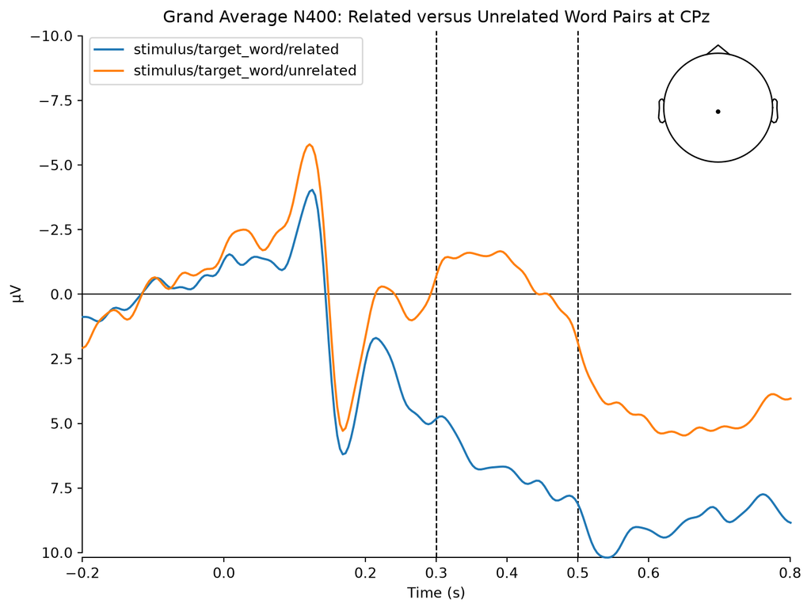

```python
selected_electrode = "CPz"

analysis_window_start = 0.3
analysis_window_end = 0.5

plot_title = (
    "Grand Average N400: Related versus "
    "Unrelated Word Pairs at CPz"
)

print("Available conditions:", list(grand_avs))

plot_evokeds(
    grand_avs,
    picks=selected_electrode,
    invert_y=True,
    title=plot_title,
    vlines=[
        analysis_window_start,
        analysis_window_end
    ]
)
```

**Figure 1.** Grand-average event-related potentials for semantically related and unrelated target words at electrode CPz. The vertical dashed lines indicate the N400 analysis window (300–500 ms). Negative voltage is plotted upward.

The grand-average waveforms demonstrated a clear difference between semantically related and unrelated target words during the N400 analysis window. Unrelated targets elicited a more negative-going response than related targets throughout the 300–500 ms interval. The unrelated condition exhibited a sustained negative deflection of approximately −1 to −2 µV between 300 and 400 ms, whereas the related condition demonstrated a positive-going amplitude of approximately +5 to +7 µV over the same interval. The separation between conditions persisted until 500 ms, consistent with the expected direction and temporal characteristics of the N400 effect described by Kappenman et al. (2021).

## Discussion and reflection

The present analysis investigated whether semantic relatedness modulated the N400 response in the ERP CORE dataset. The grand-average waveforms demonstrated a pronounced difference between conditions at CPz during the 300–500 ms post-stimulus interval. Semantically unrelated targets elicited greater negative-going activity than related targets, consistent with the characteristic N400 effect reported by Kappenman et al. (2021). This pattern supports the interpretation that semantic context facilitates the processing of related target words, reducing N400 negativity through the activation of associated semantic representations (Kutas & Federmeier, 2011; Lau et al., 2008).

The findings provide evidence of a descriptive replication of the semantic relatedness effect, particularly regarding its direction and timing at the representative centroparietal electrode CPz. However, the grand-average waveforms also exhibited substantial positive-going deflections following approximately 150 ms, with sustained positivity in the related condition throughout the N400 window. These differences in waveform morphology may reflect variations in preprocessing procedures, referencing, artefact rejection or the number of retained trials. Furthermore, the simplified analysis pipeline does not reproduce all artefact-correction and trial-selection procedures employed by Kappenman et al. (2021), potentially limiting the comparability of absolute amplitudes.

This analysis demonstrated that successful code execution does not necessarily guarantee scientifically valid results. An initial programming error inadvertently restricted the grand average to one participant, producing markedly different waveforms. Correcting the participant-averaging procedure revealed a clearer N400 effect and highlighted the importance of systematically validating intermediate outputs. I consequently developed a deeper understanding of reproducibility as a process of verifying data integrity, critically evaluating methodological choices and ensuring that neuroscientific interpretations are supported by accurately processed data.

## Declaration on Generative AI use

Generative AI (ChatGPT, OpenAI) was not utalised to assist with the writing of this report

## References

Kappenman, E. S., Farrens, J. L., Zhang, W., Stewart, A. X., & Luck, S. J. (2021). ERP CORE: An open resource for human event-related potential research. *NeuroImage, 225*, Article 117465. https://doi.org/10.1016/j.neuroimage.2020.117465

Kutas, M., & Federmeier, K. D. (2011). Thirty years and counting: Finding meaning in the N400 component of the event-related brain potential (ERP). *Annual Review of Psychology, 62*, 621–647. https://doi.org/10.1146/annurev.psych.093008.131123

Kutas, M., & Hillyard, S. A. (1980). Reading senseless sentences: Brain potentials reflect semantic incongruity. *Science, 207*(4427), 203–205. https://doi.org/10.1126/science.7350657

Lau, E. F., Phillips, C., & Poeppel, D. (2008). A cortical network for semantics: (de)constructing the N400. *Nature Reviews Neuroscience, 9*, 920–933. https://doi.org/10.1038/nrn2532